# Rasmann data wrangling

```r
library(skimr)
```

```r
raw <- read_delim(here("data", "Defossez et al.", "all_data_ind.csv"), ";") %>% clean_names()
```

| species | id | species_2 | treatment | replicate | treatment_nb | leaveas_area_nub | collection_date | x_coord | y_coord | altitude | avg_altitude | altitude_class | av_weight | av_sla | percent_damage | av_height | av_photosynt | av_toughness | weight_mg_cn | nitrogen_percent | carbon_percent | cn | hydrogen_percent | gls_total | gls_c | gls_induced | voc_total | vocs_c | vocs_induced |
| --- | --- | --- | --- | --- | --- | --- | --- | --- | --- | --- | --- | --- | --- | --- | --- | --- | --- | --- | --- | --- | --- | --- | --- | --- | --- | --- | --- | --- | --- |
| alpina | ALP0608C1 | C_alpina | C | 1 | C1 | NA | 6.08 | 672756 | 147683 | 2490 | 2450.2982 | H | 192.0 | 18.998745 | 0.0 | 3.5 | 44.46667 | 32.00000 | 10.15 | 3.294000 | 42.53100 | 12.911658 | 5.967000 | 59.8147781 | 59.8147781 | -11.167523 | 4.478075 | 4.478075 | 4.17264851 |
| alpina | ALP0608C2 | C_alpina | C | 2 | C2 | NA | 6.08 | 672756 | 147683 | 2490 | 2450.2982 | H | 103.0 | 14.941207 | 0.0 | 2.0 | 36.76667 | 30.00000 | 7.90 | 3.633000 | 40.33500 | 11.102395 | 5.580000 | 97.4466809 | 97.4466809 | -48.799426 | 8.591203 | 8.591203 | 0.05952006 |
| alpina | ALP0608C3 | C_alpina | C | 3 | C3 | NA | 6.08 | 672756 | 147683 | 2490 | 2450.2982 | H | 59.0 | 15.868206 | 7.5 | 6.0 | 32.76667 | 72.00000 | 5.55 | 3.447000 | 39.88500 | 11.570931 | 5.439000 | 55.2202735 | 55.2202735 | -6.573018 | 2.974439 | 2.974439 | 5.67628403 |
| alpina | ALP0608C4 | C_alpina | C | 4 | C4 | NA | 6.08 | 672756 | 147683 | 2490 | 2450.2982 | H | 76.0 | 16.024817 | 5.0 | 4.0 | 48.26667 | 60.00000 | 6.39 | 3.368000 | 40.07900 | 11.899941 | 5.586000 | 41.2683990 | 41.2683990 | 7.378856 | 9.113187 | 9.113187 | -0.46246350 |
| alpina | ALP0608JA1 | C_alpina | JA | 1 | JA1 | NA | 6.08 | 672756 | 147683 | 2490 | 2450.2982 | H | 253.0 | 13.339960 | 5.0 | 4.5 | 38.33333 | 62.00000 | 10.44 | 4.742000 | 40.08300 | 8.452763 | 5.766000 | 60.0896602 | NA | NA | 6.536295 | NA | NA |
| alpina | ALP0608JA2 | C_alpina | JA | 2 | JA2 | NA | 6.08 | 672756 | 147683 | 2490 | 2450.2982 | H | 272.0 | 14.310198 | 5.0 | 5.0 | 34.13333 | 30.00000 | 10.25 | 4.374000 | 40.10900 | 9.169867 | 5.643000 | 9.0789214 | NA | NA | 10.191130 | NA | NA |
| alpina | ALP0608JA3 | C_alpina | JA | 3 | JA3 | NA | 6.08 | 672756 | 147683 | 2490 | 2450.2982 | H | 148.0 | 13.904132 | 5.0 | 5.0 | 34.73333 | 20.00000 | 10.01 | 4.267000 | 40.68300 | 9.534333 | 5.784000 | 76.3639120 | NA | NA | 5.262597 | NA | NA |
| alpina | ALP0608JA4 | C_alpina | JA | 4 | JA4 | NA | 6.08 | 672756 | 147683 | 2490 | 2450.2982 | H | 166.0 | 22.513968 | 0.0 | 6.5 | 41.70000 | 54.00000 | 8.68 | 3.573000 | 41.17300 | 11.523370 | 5.700000 | 49.0565276 | NA | NA | 12.612870 | NA | NA |
| amara | AMA0608C1 | C_amara | C | 1 | C1 | NA | 6.08 | 702633 | 150902 | 1490 | 954.1897 | M | 123.0 | 12.460317 | 5.0 | 25.0 | 29.03333 | 43.00000 | 10.26 | 4.892000 | 38.93000 | 7.957890 | 5.643000 | 62.1824063 | 62.1824063 | -16.881030 | 29.160173 | 29.160173 | 137.20406330 |
| amara | AMA0608C2 | C_amara | C | 2 | C2 | NA | 6.08 | 702633 | 150902 | 1490 | 954.1897 | M | 467.0 | 12.323391 | 10.0 | 20.0 | 32.26667 | 54.00000 | 9.86 | 3.986000 | 37.92300 | 9.514049 | 5.644000 | 43.3658601 | 43.3658601 | 1.935516 | 5.279340 | 5.279340 | 161.08489670 |

[output cut: 220 more lines]

Within each population, they selected 8 plants, half of which were treated with JA. Some species have multiple populations.

- `species`: specific epithet, don’t use–has wrong number of unique values
- `id`: unique plant ID, includes species abbrev., population number, induction treatment, and rep number
- `species_2`: Scientific name
- `treatment`: whether a plant was treated with jasmonic acid (JA) a control plan (C) or NA???
- `replicate`
- `treatment_nb`: don’t use
- `leaveas_area_nub`
- `collection_date`
- `x_coord`
- `y_coord`
- `altitude`: Actual altitude where the plant was collected
- `avg_altitude`: Average altitude of the species from Swiss-wide occurance data
- `altitude_class`: Character representation of altitude, don’t use.
- `av_weight`: weight of each plant
- `av_sla`: specific leaf area (ratio of 6mm diameter leaf disc area to its dry mass ($mm^2/mg$)
- `percent_damage`: ordinal percentage eaten (100% = all leaves gone)
- `av_height`: height of each plant
- `av_photosynt`: Actually chlorophyll content (SPAD)
- `av_toughness`: leaf toughness
- `weight_mg_cn`: sample weight for carbon/nitrogen analysis, ignore
- `nitrogen_percent`: %N content
- `carbon_percent`: %C content
- `cn`: Carbon to nitrogen ratio
- `hydrogen_percent`: ignore
- `gls_total`: glucosinolates in this specific plant
- `gls_c`: glucosinolates in this specific plant for control plants
- `gls_induced`: Mean `gls_total`for JA treated plants in this population - `gls_c`
- `voc_total`: VOCs in this specific plant
- `vocs_C`: VOCs in this specifc plant for control plants
- `vocs_induced`: Mean `voc_total` for JA treated plants in this population (species?) - `vocs_c`

# Select columns

| species_2 | treatment | altitude | avg_altitude | av_weight | av_sla | percent_damage | av_height | av_photosynt | av_toughness | nitrogen_percent | carbon_percent | gls_total | voc_total |
| --- | --- | --- | --- | --- | --- | --- | --- | --- | --- | --- | --- | --- | --- |
| C_alpina | C | 2490 | 2450.2982 | 192.0 | 18.998745 | 0.0 | 3.5 | 44.46667 | 32.00000 | 3.294000 | 42.53100 | 59.8147781 | 4.478075 |
| C_alpina | C | 2490 | 2450.2982 | 103.0 | 14.941207 | 0.0 | 2.0 | 36.76667 | 30.00000 | 3.633000 | 40.33500 | 97.4466809 | 8.591203 |
| C_alpina | C | 2490 | 2450.2982 | 59.0 | 15.868206 | 7.5 | 6.0 | 32.76667 | 72.00000 | 3.447000 | 39.88500 | 55.2202735 | 2.974439 |
| C_alpina | C | 2490 | 2450.2982 | 76.0 | 16.024817 | 5.0 | 4.0 | 48.26667 | 60.00000 | 3.368000 | 40.07900 | 41.2683990 | 9.113187 |
| C_alpina | JA | 2490 | 2450.2982 | 253.0 | 13.339960 | 5.0 | 4.5 | 38.33333 | 62.00000 | 4.742000 | 40.08300 | 60.0896602 | 6.536295 |
| C_alpina | JA | 2490 | 2450.2982 | 272.0 | 14.310198 | 5.0 | 5.0 | 34.13333 | 30.00000 | 4.374000 | 40.10900 | 9.0789214 | 10.191130 |
| C_alpina | JA | 2490 | 2450.2982 | 148.0 | 13.904132 | 5.0 | 5.0 | 34.73333 | 20.00000 | 4.267000 | 40.68300 | 76.3639120 | 5.262597 |
| C_alpina | JA | 2490 | 2450.2982 | 166.0 | 22.513968 | 0.0 | 6.5 | 41.70000 | 54.00000 | 3.573000 | 41.17300 | 49.0565276 | 12.612870 |
| C_amara | C | 1490 | 954.1897 | 123.0 | 12.460317 | 5.0 | 25.0 | 29.03333 | 43.00000 | 4.892000 | 38.93000 | 62.1824063 | 29.160173 |
| C_amara | C | 1490 | 954.1897 | 467.0 | 12.323391 | 10.0 | 20.0 | 32.26667 | 54.00000 | 3.986000 | 37.92300 | 43.3658601 | 5.279340 |

[output cut: 148 more lines]

| species_2 | treatment | altitude | avg_altitude | av_weight | av_sla | percent_damage | av_height | av_photosynt | av_toughness | nitrogen_percent | carbon_percent | gls_total | voc_total |
| --- | --- | --- | --- | --- | --- | --- | --- | --- | --- | --- | --- | --- | --- |
| C_alpina | C | 2490 | 2450.2982 | 192.0 | 18.998745 | 0.0 | 3.5 | 44.46667 | 32.00000 | 3.294000 | 42.53100 | 59.8147781 | 4.478075 |
| C_alpina | C | 2490 | 2450.2982 | 103.0 | 14.941207 | 0.0 | 2.0 | 36.76667 | 30.00000 | 3.633000 | 40.33500 | 97.4466809 | 8.591203 |
| C_alpina | C | 2490 | 2450.2982 | 59.0 | 15.868206 | 7.5 | 6.0 | 32.76667 | 72.00000 | 3.447000 | 39.88500 | 55.2202735 | 2.974439 |
| C_alpina | C | 2490 | 2450.2982 | 76.0 | 16.024817 | 5.0 | 4.0 | 48.26667 | 60.00000 | 3.368000 | 40.07900 | 41.2683990 | 9.113187 |
| C_alpina | JA | 2490 | 2450.2982 | 253.0 | 13.339960 | 5.0 | 4.5 | 38.33333 | 62.00000 | 4.742000 | 40.08300 | 60.0896602 | 6.536295 |
| C_alpina | JA | 2490 | 2450.2982 | 272.0 | 14.310198 | 5.0 | 5.0 | 34.13333 | 30.00000 | 4.374000 | 40.10900 | 9.0789214 | 10.191130 |
| C_alpina | JA | 2490 | 2450.2982 | 148.0 | 13.904132 | 5.0 | 5.0 | 34.73333 | 20.00000 | 4.267000 | 40.68300 | 76.3639120 | 5.262597 |
| C_alpina | JA | 2490 | 2450.2982 | 166.0 | 22.513968 | 0.0 | 6.5 | 41.70000 | 54.00000 | 3.573000 | 41.17300 | 49.0565276 | 12.612870 |
| C_amara | C | 1490 | 954.1897 | 123.0 | 12.460317 | 5.0 | 25.0 | 29.03333 | 43.00000 | 4.892000 | 38.93000 | 62.1824063 | 29.160173 |
| C_amara | C | 1490 | 954.1897 | 467.0 | 12.323391 | 10.0 | 20.0 | 32.26667 | 54.00000 | 3.986000 | 37.92300 | 43.3658601 | 5.279340 |

[output cut: 140 more lines]

```
PLS
150 samples x 7 variables and 1 response
standard scaling of predictors and response(s)
162 (14%) NAs
```

|  | R2X(cum) | R2Y(cum) | Q2(cum) | RMSEE | pre | ort | pR2Y | pQ2 |
| --- | --- | --- | --- | --- | --- | --- | --- | --- |
| Total | 0.242 | 0.367 | 0.336 | 462 | 1 | 0 | 0.05 | 0.05 |

```
Single component model: only 'overview' and 'permutation' (in case of single response (O)PLS(-DA)) plots available
```

```
PLS
150 samples x 7 variables and 1 response
standard scaling of predictors and response(s)
162 (14%) NAs
```

|  | R2X(cum) | R2Y(cum) | Q2(cum) | RMSEE | pre | ort | pR2Y | pQ2 |
| --- | --- | --- | --- | --- | --- | --- | --- | --- |
| Total | 0.242 | 0.367 | 0.336 | 462 | 1 | 0 | 0.05 | 0.05 |

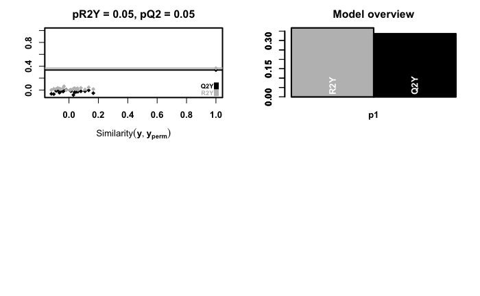

```r
opls(X, test$altitude)
```

umm, getting error when i don’t include percent damage at all but not when i include it then remove it with select()????????

```r
summary(out1)
```

```
Data:   X dimension: 87 8
    Y dimension: 87 1
Fit method: kernelpls
Number of components considered: 4

VALIDATION: RMSEP
Cross-validated using 87 leave-one-out segments.
       (Intercept)  1 comps  2 comps  3 comps  4 comps
CV           653.7    638.4    481.1    465.5    461.5
adjCV        653.7    638.4    480.9    465.4    461.3

TRAINING: % variance explained
          1 comps  2 comps  3 comps  4 comps
X          99.578    99.73    99.92    99.96
altitude    6.598    49.44    54.22    56.68
```

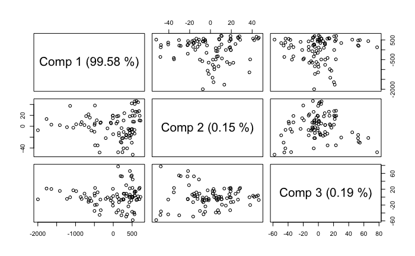

# Figure out populations within species for grouping